# Tabular Data Assignment

## The Data Source

This data comes from Analyze Boston: https://data.boston.gov/dataset/city-of-boston-utility-data. It was collected by the City of Boston and gives the opportunity to make important insights into how the City of Boston uses tax dollars to pay for energy. This energy is on one hand a necessity, since Boston gets really cold in the winter, and on the other hand it is an expense that the city would like to minimize. Thus it is important for them to have this data in order to make decisions about utility prices in the future.

```r
data <- read_csv("./data/tmp2_agrbe1.csv")
# Get total cost per utility for each month of each year
total_cost <- data %>%
  select("InvoiceDate", "EnergyTypeName", "TotalCost") %>%
  group_by(month(InvoiceDate), year(InvoiceDate), EnergyTypeName) %>%
  summarize(TotalCost = sum(TotalCost) / 1000000) %>%
  ungroup()
colnames(total_cost) <- c("InvoiceMonth", "InvoiceYear", "EnergyTypeName", "TotalCost")

# Get average cost per utility for each month across all years
total_cost <- total_cost %>%
  group_by(InvoiceMonth, EnergyTypeName) %>%
  summarize(mean(TotalCost)) %>%
  ungroup()
colnames(total_cost) <- c("InvoiceMonth", "EnergyTypeName", "TotalCost")
```

## The Questions

I had a hunch that the City of Boston pays more for utilities during winter months. I wanted to check if this was true.

There are three date columns in this data. “InvoiceDate”, “FromDate”, and “ToDate”. Of these, I chose to use the “InvoiceDate” somewhat arbitrarily. In almost every case, it coincides with the “ToDate”. What this means is that later, when looking at the plots, it’s important to consider that the information in some cases may refer to the previous month (so the whole graph should be shifted back a little bit). I don’t think this will have a huge impact on the questions I am trying to answer.

The other column of interest is TotalCost, in USD. This roughly correlates to consumption, though the relationship there would touch on policy and economics in a way that I don’t want to get into for this project. Thus, instead of asking “how much do people use utilities”, I ask “how much do people pay for utilities”. This is a much easier question to deal with, and it has the added bonus of equating all of the different types of utilities under the same unit of dollars.

Lastly, I would like to consider the different types of utilities and how they compare to each other in cost. I want to see how much the City of Boston spends on Natural Gas vs Electricity, etc. It is strange that Oil is labelled “#2 Oil” in this dataset, however it is consistent, so I am okay with it.

## The Plots

The following is a plot of total money spent on utilities by the City of Boston grouped by month.

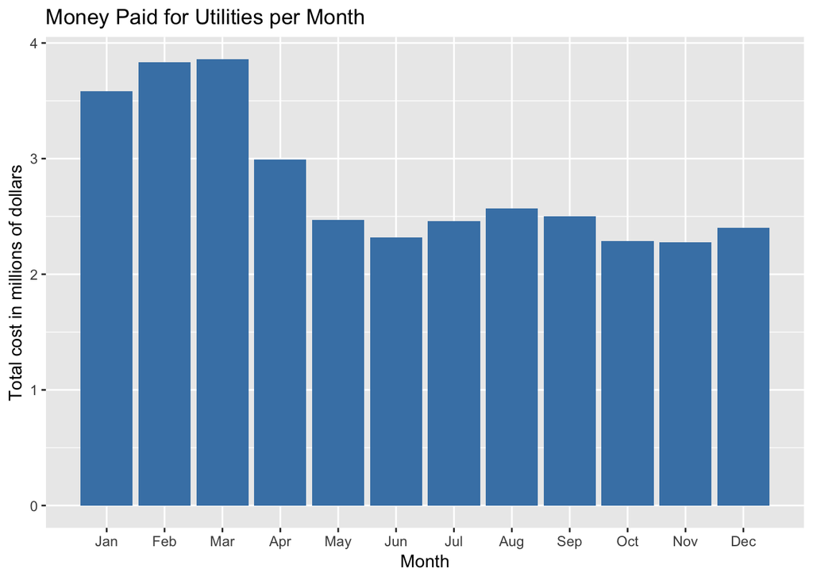

It would be interesting to see the breakdown by utility type.

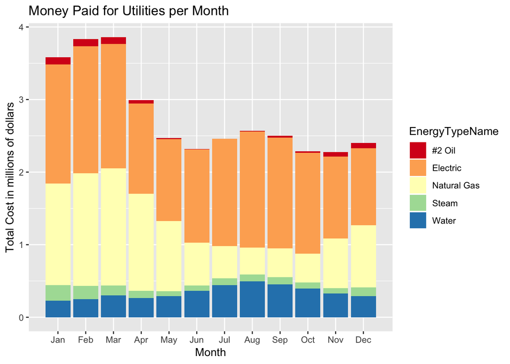

```r
ggplot(data = total_cost) +
   aes(x = InvoiceMonth, y=TotalCost, fill = EnergyTypeName) +
   geom_col() +
   labs(title = "Money Paid for Utilities per Month") +
   xlab(label = "Month") +
   ylab(label = "Total Cost in millions of dollars") +
   scale_x_discrete(limits = month.abb) +
   scale_fill_brewer(palette="Spectral")
```

In this plot I have split each bar into its own “pie chart” of sorts. Now it is clear which utilities take up more money in which parts of the year. For example, water seems mostly flat, with slightly more use in the later months of summer. Electricity has two peaks, in February and in August, probably for heating and air conditioning respectively. Natural gas is used much more in the winter than in the summer, probably for heating as well.

These trends can more clearly be illustrated with a line graph.

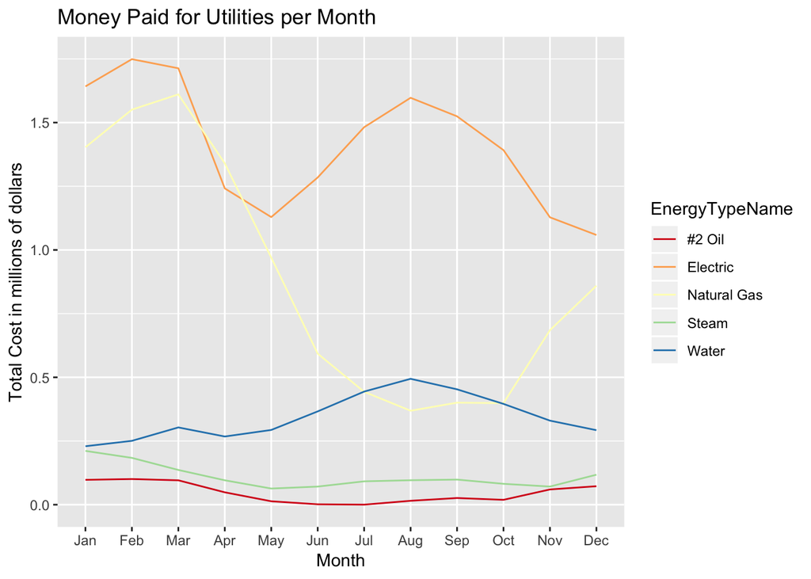

```r
ggplot(data = total_cost) +
   aes(x = InvoiceMonth, y=TotalCost, group = EnergyTypeName) +
   geom_line(aes(color=EnergyTypeName)) +
   scale_color_brewer(palette="Spectral") +
   labs(title = "Money Paid for Utilities per Month") +
   xlab(label = "Month") +
   ylab(label = "Total Cost in millions of dollars") +
   scale_x_discrete(limits = month.abb)
```

We can see on this graph that electricity and natural gas are paid for together in winter months, while in the summer they diverge dramatically. Water expenditure peaks in August, when it is briefly more costly than Natural Gas.

## Conclusions

This data can be used to try to get an insight into how much money it takes to keep Boston running from an energy perspective, and it can help predict how much money Boston will need to set aside for different utilities at different times of the year.

It can also be used to hypothesise the effect of changing costs of utilities.